# DisturbanceNotebook

21 12 2021

### Импорт библиотек

Импортируем библиотеки:

```r
library(ggplot2)
library(stats)
library(utils)
library(caTools)
library(lmtest)
```

### Импорт данных и фильтрация

## Импорт

Загрузим данные, полученные путём опроса (данные должны быть в кодирвоке ANSI):

```r
raw_data <- read.csv("data1.csv", sep=";")
```

## Фильртация

Отфильтруем данные:

```r
filtered_data <- subset(raw_data,
                        Сколько.вам.лет >= 18
                        & Сколько.вам.лет <= 24
                        & Если.не.брать.в.расчёт.время.на.сон..работу.и.учёбу..в.том.числе.выполнение.домашнего.задания...сколько..примерно..свободного.времени.у.вас.остаётся..в.минутах.. >= 0
                        & Если.не.брать.в.расчёт.время.на.сон..работу.и.учёбу..в.том.числе.выполнение.домашнего.задания...сколько..примерно..свободного.времени.у.вас.остаётся..в.минутах..< 720
                        & Сколько.времени.вы.тратите.на.сон..в.часах.. < 16)
```

### Интерпретация ответов на тест Спилберга-Ханина

Выделим из опроса вопросы и ответы, относящиеся к тесту Спилберга-Ханина:

```r
spilbergHaninTestAnswers <- filtered_data[, 14:53]
```

Преобразуем ответы в баллы в соответствии с тестом

```r
mapping <- c('Нет это совсем не так' = 1, 'Пожалуй так' = 2, 'Верно' = 3, 'Совершенно верно' = 4)
for(i in 1:length(spilbergHaninTestAnswers[,1]))
{
  temp <- vector(mode="integer", length=length(spilbergHaninTestAnswers[1,]))
  for (j in 1:length(spilbergHaninTestAnswers[1,]))
  {
    temp[j] <- mapping[spilbergHaninTestAnswers[i,j]]
  }
  spilbergHaninTestAnswers[i, ] <- temp
}
```

Реализуем функции, дающие оценку степени тревожности в соответствии с тестом:

```r
get_factor <- function(number)
{
  #disturbance_factors <- c("low", "middle", "high")
  #estimate <- ifelse(number <= 30,
  #                      disturbance_factors[1],
  #                      ifelse(number >= 31 & number <= 45,
  #                             disturbance_factors[2],
  #                             disturbance_factors[3]))
  #return(estimate)

  disturbance_factors <- c("low", "high")
  estimate <- ifelse(number <= 38,
                        disturbance_factors[1],
                        disturbance_factors[2])
  return(estimate)
}

get_spliberg_hanin_test_interp <- function(row)
{
  situational_disturbance_estimate <- sum(as.numeric(row[c(3, 4, 6, 7, 9, 12, 13, 14, 17, 18)])) - sum(as.numeric(row[c(1, 2, 5, 8, 10, 11, 15, 16, 19, 20)]))
  personal_disturbance_extimate <- sum(as.numeric(row[c(22, 23, 24, 25, 28, 31, 32, 34, 35, 37, 38, 40)])) - sum(as.numeric(row[c(21, 26, 27, 30, 33, 36, 39)])) + 35
  test_results <- data.frame(Situational = c(get_factor(situational_disturbance_estimate)), Personal = c(get_factor(personal_disturbance_extimate)))
  return(test_results)
}
```

Составим столбцы с результатами теста Спилберга-Ханина:

```r
spilbergHaninResult_situational <- vector(length=length(spilbergHaninTestAnswers[,1]))
spilbergHaninResult_personal <- vector(length=length(spilbergHaninTestAnswers[,1]))

for (i in 1:length(spilbergHaninTestAnswers[,1]))
{
  results <- get_spliberg_hanin_test_interp(spilbergHaninTestAnswers[i,])
  spilbergHaninResult_situational[i] <- results$Situational[1]
  spilbergHaninResult_personal[i] <- results$Personal[1]
}
```

Добавим полученные столбцы в выборку:

```r
filtered_data$SituationalDisturbance <- as.factor(spilbergHaninResult_situational)
filtered_data$PersonalDisturbance <- as.factor(spilbergHaninResult_personal)
```

### Подготовка данных к построению модели

Построим выборку на основе имеющейся, выделим в ней столбцы, по которым будет строиться модель:

```r
finished_data <- filtered_data[, 4:13]
finished_data <- cbind(finished_data, filtered_data[,54:56])
colnames(finished_data) <- c('Age', 'Sex', 'IsStudying', 'IsWorking', 'Music', 'FreeTime', 'SleepTime', 'NervousPeriod', 'ChronicWeak', 'Earning', 'IsDisturbed', 'SituationalDisturbance', 'PersonalDisturbance')
```

Выведем краткую сводку по выбокре:

```r
summary(finished_data)
```

```
##       Age            Sex             IsStudying         IsWorking
##  Min.   :18.00   Length:47          Length:47          Length:47
##  1st Qu.:20.00   Class :character   Class :character   Class :character
##  Median :21.00   Mode  :character   Mode  :character   Mode  :character
##  Mean   :20.64
##  3rd Qu.:22.00
##  Max.   :24.00
##     Music              FreeTime       SleepTime      NervousPeriod
##  Length:47          Min.   :  0.0   Min.   : 5.000   Length:47
##  Class :character   1st Qu.:120.0   1st Qu.: 6.000   Class :character
##  Mode  :character   Median :180.0   Median : 7.000   Mode  :character
##                     Mean   :214.7   Mean   : 7.191
##                     3rd Qu.:300.0   3rd Qu.: 8.000
##                     Max.   :400.0   Max.   :10.000
##  ChronicWeak          Earning          IsDisturbed
##  Length:47          Length:47          Length:47
##  Class :character   Class :character   Class :character
##  Mode  :character   Mode  :character   Mode  :character
##
##
##
##  SituationalDisturbance PersonalDisturbance
##  low:47                 high:35
##                         low :12
##
##
##
##
```

Как видим, многие категориальные переменные у нас заданы как строчные, а не категориальные, исправим это:

```r
finished_data$Sex <- as.factor(finished_data$Sex)
finished_data$ChronicWeak <- as.factor(finished_data$ChronicWeak)
finished_data$IsStudying <- as.factor(finished_data$IsStudying)
finished_data$Earning <- as.factor(finished_data$Earning)
finished_data$IsWorking <- as.factor(finished_data$IsWorking)
finished_data$IsDisturbed <- as.factor(finished_data$IsDisturbed)
finished_data$Music <- as.factor(finished_data$Music)
```

Так же мы можем заметить, что **SituationalDisturbance** для всех записей принимает значений **low**, что делает его неинформативным. Удалим его из выборки:

```r
finished_data <- subset(finished_data, select=-c(SituationalDisturbance))
```

Посмотрим теперь статистику по выборке:

```r
summary(finished_data)
```

```
##       Age        Sex    IsStudying IsWorking
##  Min.   :18.00   Ж:25   Да :41     Да :21
##  1st Qu.:20.00   М:22   Нет: 6     Нет:26
##  Median :21.00
##  Mean   :20.64
##  3rd Qu.:22.00
##  Max.   :24.00
##                                                    Music       FreeTime
##  Классическую (Моцарт, Бах и т.д.)                    : 1   Min.   :  0.0
##  Лёгкая (поп, рэп)                                    : 6   1st Qu.:120.0
##  Умеренная (панк-рок, альтернативный рок, гранж, глэм): 8   Median :180.0
##  Я меломан                                            :32   Mean   :214.7
##                                                             3rd Qu.:300.0
##                                                             Max.   :400.0
##    SleepTime      NervousPeriod      ChronicWeak                  Earning
##  Min.   : 5.000   Length:47          Да :19      до 15 тыс. руб       :28
##  1st Qu.: 6.000   Class :character   Нет:28      от 15 до 30 тыс. руб :12
##  Median : 7.000   Mode  :character               от 30 до 60 тыс. руб : 4
##  Mean   : 7.191                                  от 60 тыс. руб и выше: 3
##  3rd Qu.: 8.000
##  Max.   :10.000
##  IsDisturbed PersonalDisturbance
##  Да :28      high:35
##  Нет:19      low :12
##
##
##
##
```

Упростим названия категорий для столбцов **Music**, **Earning** и **NervousPeriod**:

```r
music_mapping <- c('Классическую (Моцарт, Бах и т.д.)'='Classic', 'Лёгкая (поп, рэп)'='Light', 'Умеренная (панк-рок, альтернативный рок, гранж, глэм)'='Middle', 'Я меломан'='Meloman')
simple_music = vector(length=length(finished_data[,1]))
for (i in 1:length(finished_data[,1]))
{
  simple_music[i] <- music_mapping[as.character(finished_data$Music[i])]
}
finished_data$Music <- as.factor(simple_music)

earning_mapping <- c('до 15 тыс. руб'='less_than_15', 'от 15 до 30 тыс. руб'='from_15_to_30', 'от 30 до 60 тыс. руб'='from_30_to_60', 'от 60 тыс. руб и выше'='greater_than_60')
simple_earning = vector(length=length(finished_data[,1]))
for (i in 1:length(finished_data[,1]))
{
  simple_earning[i] <- earning_mapping[as.character(finished_data$Earning[i])]
}
finished_data$Earning <- factor(simple_earning, levels=c("less_than_15", "from_15_to_30", "from_30_to_60", "greater_than_60"))

nervous_period_mapping <- c('Крайне редко' = 'Rare', 'Пару раз в год'='SeveralPerYear', 'Раз в месяц'='OnePerMonth', 'Пару раз в месяц'='SeveralPerMonth', 'Раз в неделю'='OnePerWeek', 'Пару раз в неделю'='SeveralPerWeek', 'Раз в день'='OnePerDay', 'Пару раз в день'='SeveralPerDay')
simple_nervous_period = vector(length=length(finished_data[,1]))
for (i in 1:length(finished_data[,1]))
{
  simple_nervous_period[i] <- nervous_period_mapping[as.character(finished_data$NervousPeriod[i])]
}
finished_data$NervousPeriod <- factor(simple_nervous_period, levels=c('Rare', "SeveralPerYear", "OnePerMonth", 'SeveralPerMonth', 'OnePerWeek', 'SeveralPerWeek', 'OnePerDay'))
```

Выборка готова, можно приступить к построению модели.

### Описание выборки

Выведем и опишем базовые статистические показатели выборки:

## Age

```r
summ <- summary(finished_data$Age)
summ
```

```
##    Min. 1st Qu.  Median    Mean 3rd Qu.    Max.
##   18.00   20.00   21.00   20.64   22.00   24.00
```

Наименьшим возрастом в выборке является 18 лет.  
Наибольшим возрастом в выборке является 24 года.  
Средний возраст опрошенных является 20 лет 7-8 месяцев.  
Четверть опрошенных младше или являются 20-летними.  
Половина опрошенных младше или являются 21-летними.  
Четверть опрошенных старше или являются 22-летними.

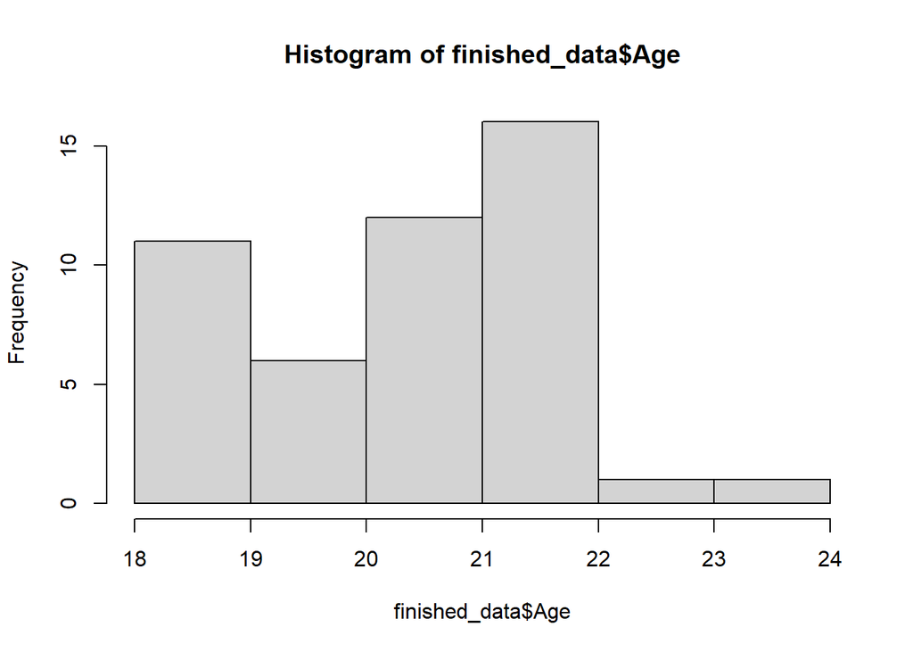

```r
hist(finished_data$Age)
```

## Sex

```r
summ <- summary(finished_data$Sex)
summ
```

```
##  Ж  М
## 25 22
```

Из опрошенных женщин - 25, мужчин - 22

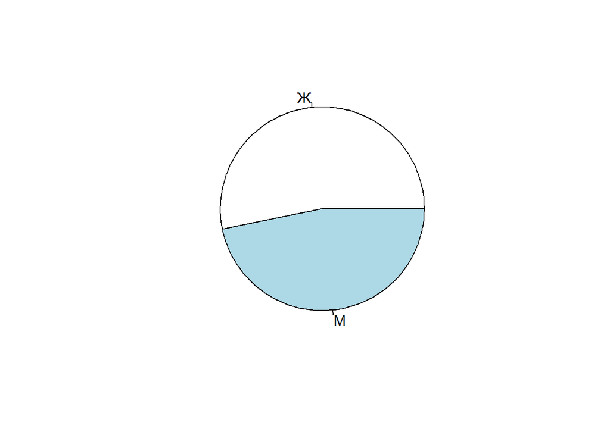

```r
pie(c(summ[["Ж"]], summ[["М"]]), labels=c("Ж", "М"))
```

## IsStudying

```r
summ <- summary(finished_data$IsStudying)
summ
```

```
##  Да Нет
##  41   6
```

Обучающихся из опрошенных 41, необучающихся 6

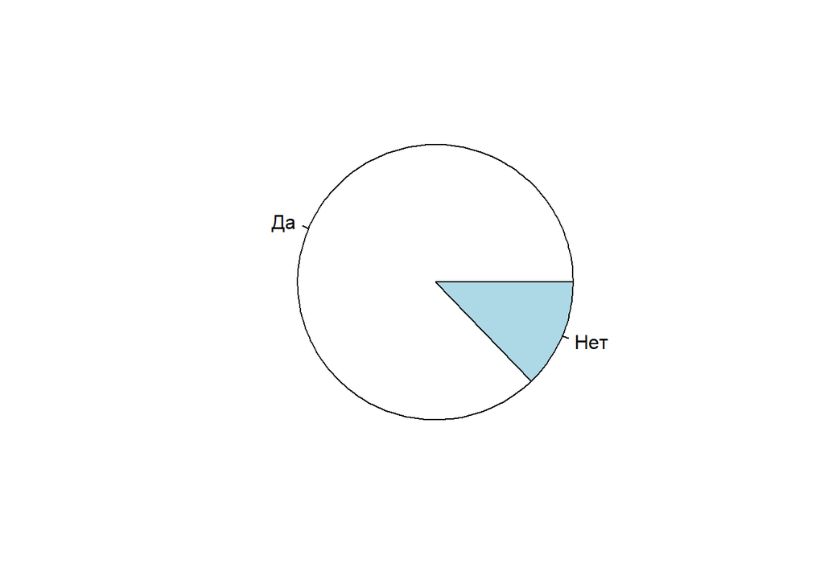

```r
pie(c(summ[["Да"]], summ[["Нет"]]), labels=c("Да", "Нет"))
```

## IsWorking

```r
summ <- summary(finished_data$IsWorking)
summ
```

```
##  Да Нет
##  21  26
```

Работающих из опрошенных 21, необчающихся - 26

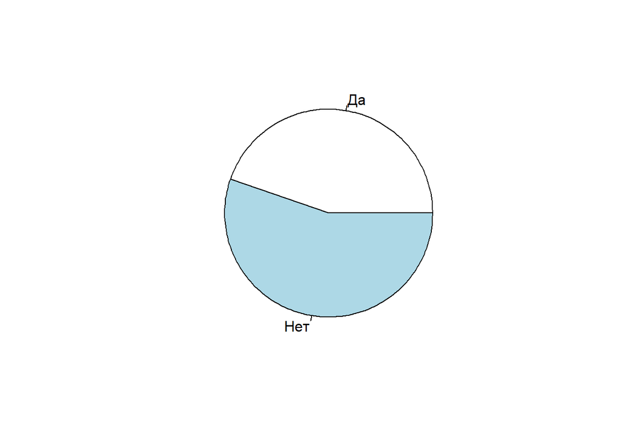

```r
pie(c(summ[["Да"]], summ[["Нет"]]), labels=c("Да", "Нет"))
```

## Music

```r
summ <- summary(finished_data$Music)
summ
```

```
## Classic   Light Meloman  Middle
##       1       6      32       8
```

Как видим, классическую музыку стоит 1 человек из выборки, лёгкую - 6, умеренную - 8, меломанов - 32.

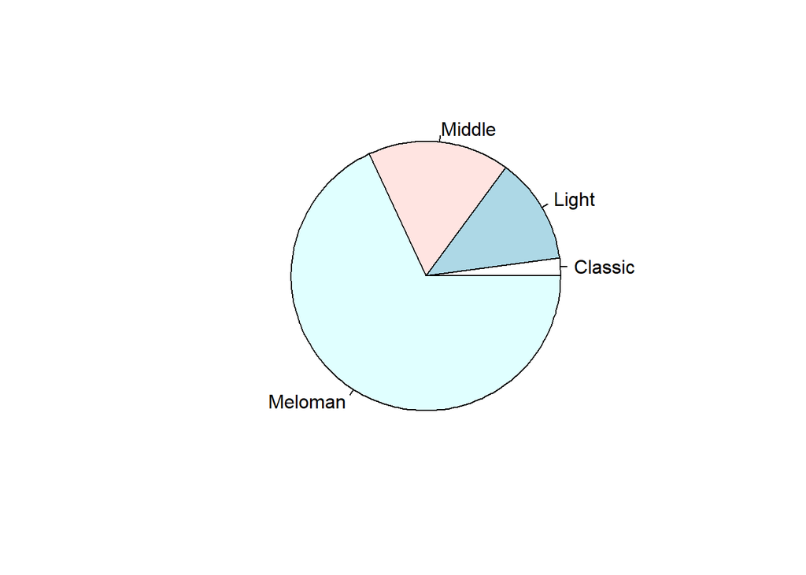

```r
pie(c(summ[["Classic"]], summ[["Light"]], summ[["Middle"]], summ[["Meloman"]]), c("Classic", "Light", "Middle", "Meloman"))
```

## FreeTime

```r
summ <- summary(finished_data$FreeTime)
summ
```

```
##    Min. 1st Qu.  Median    Mean 3rd Qu.    Max.
##     0.0   120.0   180.0   214.7   300.0   400.0
```

Минимальное свободное времяя в выборке - 0 минут, максимальное - 400 минут.  
У четверти опрошенных не более 120 минут свободного времени, у половины - не более 180. У четверти опрошенных не менее 300 минут свободного времени.  
В среднем на каждого опрошенного приходится 214.7 минут свободного времени.

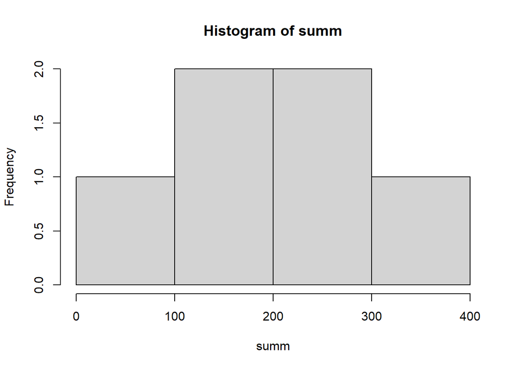

```r
hist(summ)
```

## SleepTime

```r
summ <- summary(finished_data$SleepTime)
summ
```

```
##    Min. 1st Qu.  Median    Mean 3rd Qu.    Max.
##   5.000   6.000   7.000   7.191   8.000  10.000
```

Минимальное время сна в выборке - 5 часов, максимальное 10.  
У четверти опрошенных не более 6 часов отводится на сон, у половины - не более 7. У четверти опрошенных - не менее 8 часов.  
В среднем каждый опрошенный отводит на сон 7 часов 12 минут.

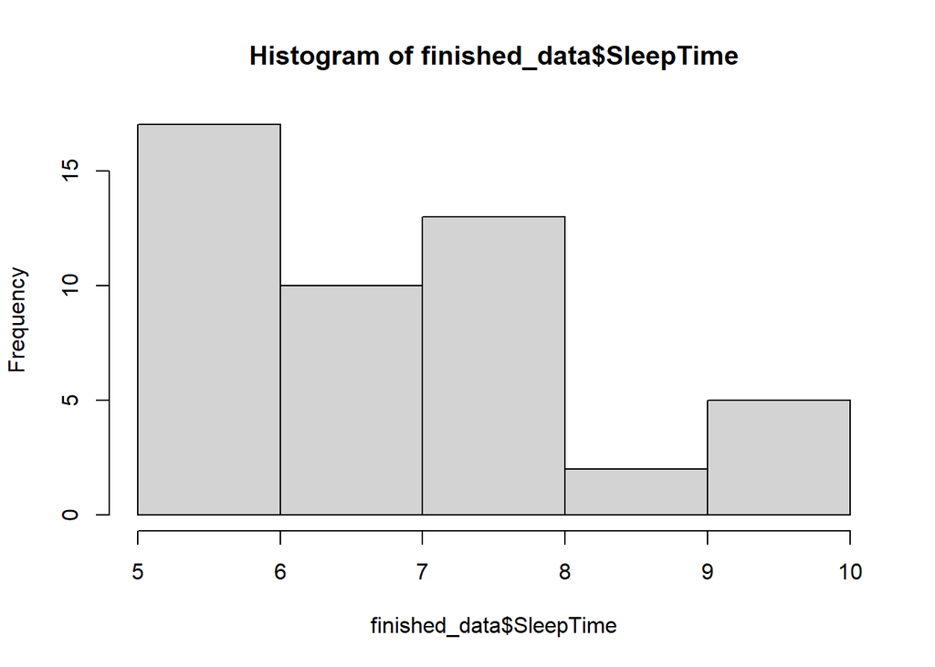

```r
hist(finished_data$SleepTime)
```

## NervousPeriod

```r
summ <- summary(finished_data$NervousPeriod)
summ
```

```
##            Rare  SeveralPerYear     OnePerMonth SeveralPerMonth      OnePerWeek
##              21               6               4               9               2
##  SeveralPerWeek       OnePerDay
##               4               1
```

Как видим, раз в день срывается 1 человек, несколько раз в неделю 4, раз в неделю 2, раз несколько раз в месяц 9, раз в месяц 4, несколько раз в год 6 и реже раза в год 21.

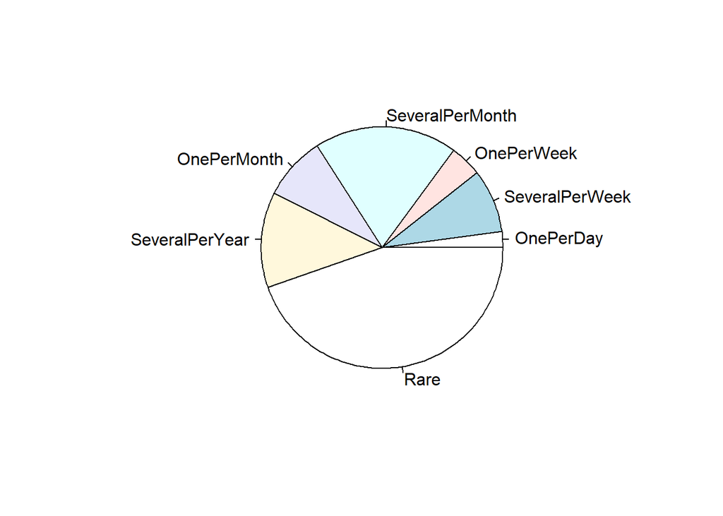

```r
pie(c(summ[["OnePerDay"]], summ[["SeveralPerWeek"]], summ[["OnePerWeek"]], summ[["SeveralPerMonth"]], summ[["OnePerMonth"]], summ[["SeveralPerYear"]], summ[["Rare"]]), c("OnePerDay", "SeveralPerWeek", "OnePerWeek", "SeveralPerMonth", "OnePerMonth", "SeveralPerYear", "Rare"))
```

## ChronicWeak

```r
summ <- summary(finished_data$ChronicWeak)
summ
```

```
##  Да Нет
##  19  28
```

Имеющих хронические болезни из опрошенных 19, неимеющих - 28

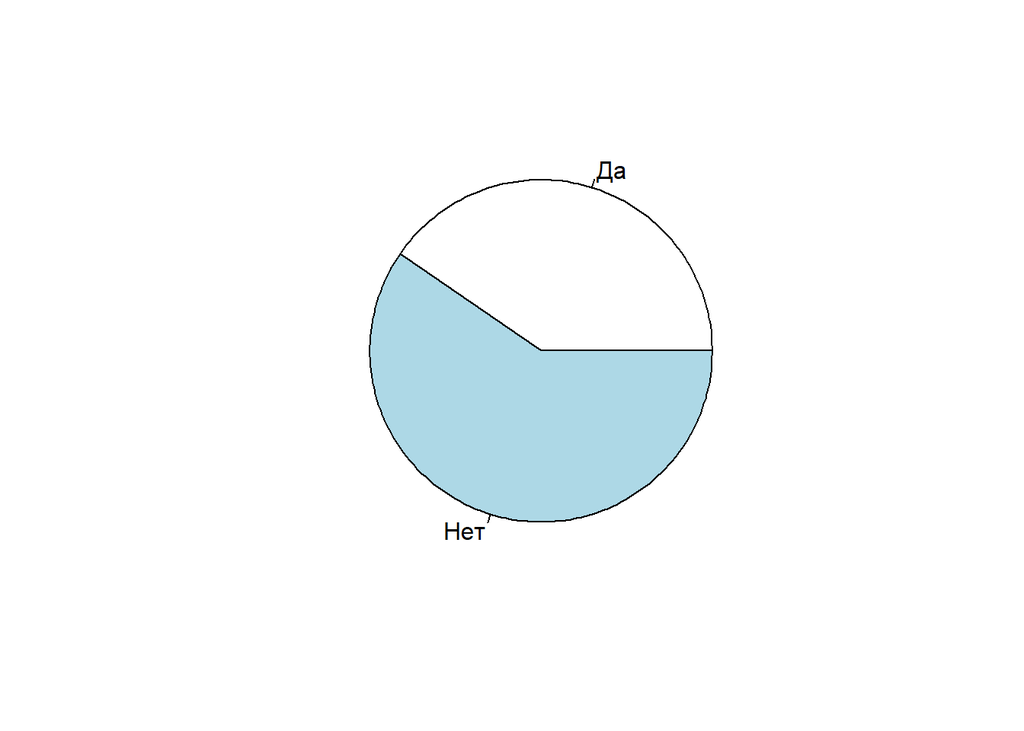

```r
pie(c(summ[["Да"]], summ[["Нет"]]), labels=c("Да", "Нет"))
```

## Earning

```r
summ <- summary(finished_data$Earning)
summ
```

```
##    less_than_15   from_15_to_30   from_30_to_60 greater_than_60
##              28              12               4               3
```

Как видим, менее 15 тыс. руб получают 28 человек, от 15 до 30 тыс получают 12, от 30 до 60 тыс руб получают 4 и более 60 тыс руб получают 3 человека.

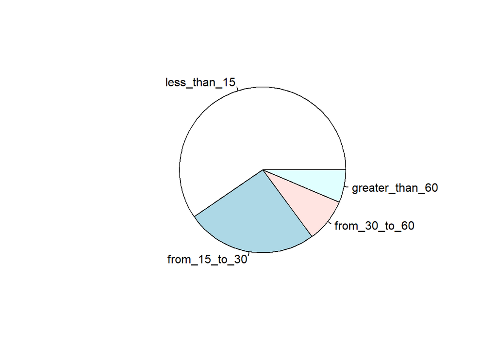

```r
pie(c(summ[["less_than_15"]], summ[["from_15_to_30"]], summ[["from_30_to_60"]], summ[["greater_than_60"]]), c("less_than_15", "from_15_to_30", "from_30_to_60", "greater_than_60"))
```

## IsDisturbed

```r
summ <- summary(finished_data$IsDisturbed)
summ
```

```
##  Да Нет
##  28  19
```

Опрошенных имеющих тревожность 28, не имеющих 19.

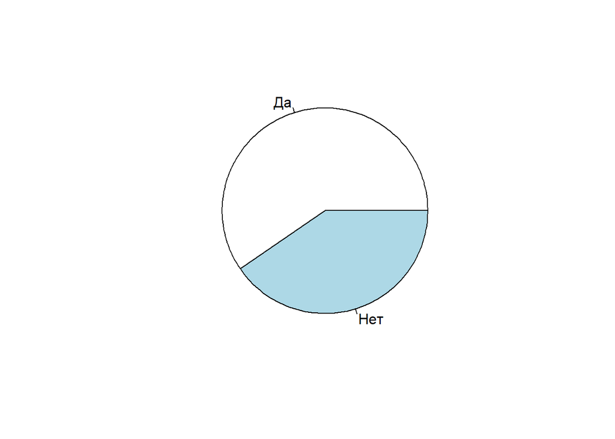

```r
pie(c(summ[["Да"]], summ[["Нет"]]), labels=c("Да", "Нет"))
```

### Проверка статистической связи

Проверим нет ли связи между независимыми и зависимой переменными. Для этого будем использовать: Коэффициент взаимной сопряженности Пирсона - показывает степень стохастической связи между дихотомической переменной и категориальной с несколькими категориями.  
Биссериальный коэффициент корреляции - показывает степень стохастической связи между дихотомической переменной и переменной, измеряемой некоторой сильной шкалой

```r
get_fi_sqr <- function(tbl)
{
  row_param <- c()
  for(i in 1:length(tbl[, 1]))
  {
    row_param[i] <- sum(tbl[i, ])
  }

  col_param <- c()
  for(i in 1:length(tbl[1, ]))
  {
    col_param[i] <- sum(tbl[, i])
  }

  fi <- 0
  for (i in 1:length(tbl[, 1]))
  {
    tempFi <- 0
    for (j in 1:length(tbl[1, ]))
    {
      tempFi <- tempFi + tbl[i, j]**2 / col_param[j]
    }

    fi <- fi + tempFi / row_param[i]
  }

  return (fi - 1)
}

library('tibble')
get_chisq <- function(tbl)
{
  row_param <- c()
  for(i in 1:length(tbl[, 1]))
  {
    row_param[i] <- sum(tbl[i, ])
  }

  col_param <- c()
  for(i in 1:length(tbl[1, ]))
  {
    col_param[i] <- sum(tbl[, i])
  }
  sum_df <- sum(tbl)

  ar <- data.frame(matrix(ncol=length(tbl[1, ]), nrow=0))
  for (i in 1:length(tbl[, 1]))
  {
    v <- c()
    for (j in 1:length(tbl[1, ]))
    {
      v[j] <- row_param[i] * col_param[j] / sum_df
    }

    ar <- rbind(ar, v)
  }

  chisq <- 0
  for (i in 1:length(tbl[, 1]))
  {
    for (j in 1:length(tbl[1, ]))
    {
      chisq <- chisq + (tbl[i, j] - ar[i, j])**2 / ar[i, j]
    }
  }

  return(chisq)
}

pearson.contingence <- function(tbl, n)
{
  fi_sqr <- get_fi_sqr(tbl)
  cont <- (sqrt(fi_sqr/(1 + fi_sqr)))
  chisq_actual <- get_chisq(tbl)
  chisq_crit <- qchisq(0.05, n-1)
  return(data.frame(Coef=c(cont), Chi_Sq_obs=c(chisq_actual), Chi_Sq_table=c(chisq_crit), IsNullHypotesisTrue=c(chisq_actual > chisq_crit)))
}
```

```r
get_biser_coeff_abs <- function(absolute_col, binary_col)
{
  N <- length(absolute_col)
  df <- data.frame(Absolute=absolute_col, Binary=binary_col)
  factors <- levels(binary_col)
  st_d <- sd(absolute_col)

  x1 <- subset(df, Binary == factors[1])
  n1 <- length(x1$Absolute)
  m1 <- mean(x1$Absolute)

  x2 <- subset(df, Binary == factors[2])
  n2 <- length(x2$Absolute)
  m2 <- mean(x2$Absolute)

  bis_coeff <- (m2 - m1) / st_d * sqrt(n1 * n2 / (N * (N - 1)))

  t_obs <- abs(bis_coeff) * sqrt((N-2)/(1 - bis_coeff**2))

  t_tab <- abs(qt(0.05, N-2))

  result_df <- data.frame(Coef=c(bis_coeff), t_obs=c(t_obs), t_table=c(t_tab), IsNullHypotesisTrue=c(t_obs<t_tab))
  return(result_df)
}
```

```r
get_rank_biser_coef_pearson <- function(df, rank_col_name, bin_col_name, alpha=0.05)
{
  ranks <- rank(df[rank_col_name])
  bin_levels <- levels(df[, bin_col_name])
  rank_bin_df <- data.frame(Ranks=ranks, Bin=df[bin_col_name])
  first_mean <- mean(subset(rank_bin_df, df[bin_col_name]==bin_levels[1])$Ranks)
  second_mean <- mean(subset(rank_bin_df, df[bin_col_name]==bin_levels[2])$Ranks)
  N <- length(ranks)
  r_rb <- 2 / N * abs(first_mean - second_mean)
  t_obs <- abs(r_rb)/sqrt(1 - r_rb**2) * sqrt(N - 2)
  t_tab <- qt(alpha/2, N-2)
  result_df <- data.frame(Coef=c(r_rb), ObservedT=t_obs, TableT=t_tab, IsNullHypotesisTrue=c(abs(t_obs)<abs(t_tab)))
  return(result_df);
}
```

```r
assoc <- function(dataframe)
{
  ac <- dataframe[1, 1]
  bc <- dataframe[1, 2]
  ad <- dataframe[2, 1]
  bd <- dataframe[2, 2]
  return((ac*bd-bc*ad)/(ac*bd+bc*ad))
}

conting <- function(dataframe)
{
  c <- dataframe[1, 1] + dataframe[1, 2]
  d <- dataframe[2, 1] + dataframe[2, 2]
  a <- dataframe[1, 1] + dataframe[2, 1]
  b <- dataframe[1, 2] + dataframe[2, 2]

  ac <- dataframe[1, 1]
  bc <- dataframe[1, 2]
  ad <- dataframe[2, 1]
  bd <- dataframe[2, 2]
  return ((ac*bd-bc*ad)/sqrt(a*b*c*d))
}
```

```r
get_pearson_cor <- function(first_col, second_col, alpha=0.05)
{
  corr <- cor(first_col, second_col)
  n <- length(first_col)
  t_obs <- corr * sqrt(n-2)/sqrt(1-corr**2)
  t_tab <- qt(alpha/2, n-2)
  result_df <- data.frame(Coef=c(corr), ObservedT=c(t_obs), TableT=c(t_tab), IsNullHypotesisTrue=c(t_obs<t_tab))
  return(result_df)
}
```

```r
get_kendall_cor <- function(first_col, second_col, alpha=0.05)
{
  corr <- cor(first_col, second_col, method=c("kendall"))
  n <- length(first_col)
  dt <- 2*(2*n+5)/(9*n*(n-1))
  z_obs <- corr / sqrt(dt)
  z_tab <- qnorm(1-alpha/2)
  result_df <- data.frame(Coef=c(corr), ObservedT=c(z_obs), TableT=c(z_tab), IsNullHypotesisTrue=c(abs(z_obs)<z_tab))
  return(result_df)
}
```

```r
get_val <- function(df)
{
  v <- ifelse(df$IsNullHypotesisTrue[1], 0, df$Coef[1])
  return (v)
}
```

Зададим таблицу, в которой будут храниться данные о связи между переменными

```r
corr_matrix <- matrix(0, nrow = length(finished_data[1,]), ncol = length(finished_data[1,]));
names <- colnames(finished_data)
rownames(corr_matrix) <- names
colnames(corr_matrix) <- names
for (n in names)
{
  corr_matrix[n, n] <- 1
}
```

## Age

Найдём связь между перменной Age и остальными переменными